# 03_construct_figuretable

Suguru Otani

2024-01-26

# load

num_time_50_cobb_douglas_0.3_AR1_I0 num_time_50_cobb_douglas_0.3_AR0_I1 num_time_50_perfect_substitute_0.3_AR1_I0 num_time_50_perfect_substitute_0.3_AR0_I1 num_time_100_cobb_douglas_0.3_AR1_I0 num_time_100_cobb_douglas_0.3_AR0_I1 num_time_100_perfect_substitute_0.3_AR1_I0 num_time_100_perfect_substitute_0.3_AR0_I1 num_time_200_cobb_douglas_0.3_AR1_I0 num_time_200_cobb_douglas_0.3_AR0_I1 num_time_200_perfect_substitute_0.3_AR1_I0 num_time_200_perfect_substitute_0.3_AR0_I1

## Stationary cobb_douglas

the match elasticity with respect to unemployment is in the range 0.5–0.7.

### num_time_50_cobb_douglas_0.3_AR1_I0

|  | Unique | Missing Pct. | Mean | SD | Min | Median | Max |  |
| --- | --- | --- | --- | --- | --- | --- | --- | --- |
| simulation_id | 100 | 0 | 50.500 | 29.011 | 1.000 | 50.500 | 100.000 |  |
| bias | 100 | 0 | -0.001 | 0.015 | -0.045 | 0.002 | 0.025 |  |
| rmse | 100 | 0 | 0.054 | 0.007 | 0.042 | 0.052 | 0.075 |  |

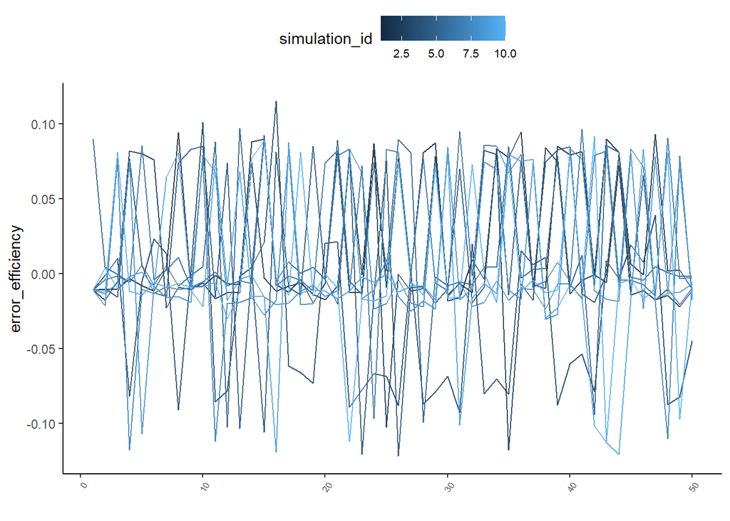

### num_time_100_cobb_douglas_0.3_AR1_I0

|  | Unique | Missing Pct. | Mean | SD | Min | Median | Max |  |
| --- | --- | --- | --- | --- | --- | --- | --- | --- |
| simulation_id | 100 | 0 | 50.500 | 29.011 | 1.000 | 50.500 | 100.000 |  |
| bias | 100 | 0 | 0.013 | 0.012 | -0.035 | 0.014 | 0.038 |  |
| rmse | 100 | 0 | 0.054 | 0.004 | 0.046 | 0.054 | 0.072 |  |

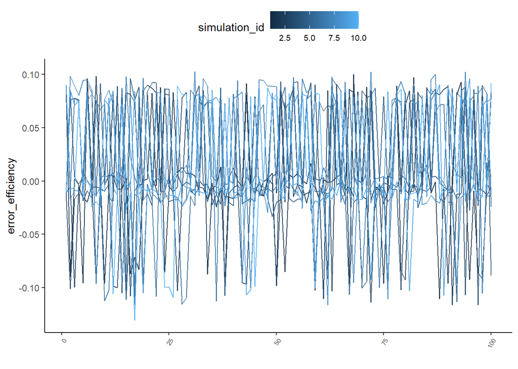

### num_time_200_cobb_douglas_0.3_AR1_I0

|  | Unique | Missing Pct. | Mean | SD | Min | Median | Max |  |
| --- | --- | --- | --- | --- | --- | --- | --- | --- |
| simulation_id | 100 | 0 | 50.500 | 29.011 | 1.000 | 50.500 | 100.000 |  |
| bias | 100 | 0 | 0.019 | 0.014 | -0.021 | 0.023 | 0.045 |  |
| rmse | 100 | 0 | 0.055 | 0.004 | 0.049 | 0.055 | 0.075 |  |

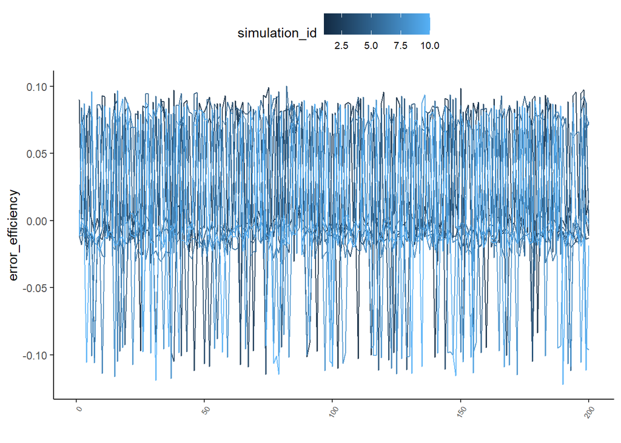

## Stationary perfect_substitute

the match elasticity with respect to unemployment is in the range 0.5–0.7.

### num_time_50_perfect_substitute_0.3_AR1_I0

|  | Unique | Missing Pct. | Mean | SD | Min | Median | Max |  |
| --- | --- | --- | --- | --- | --- | --- | --- | --- |
| simulation_id | 100 | 0 | 50.500 | 29.011 | 1.000 | 50.500 | 100.000 |  |
| bias | 100 | 0 | -0.010 | 0.020 | -0.057 | -0.010 | 0.032 |  |
| rmse | 100 | 0 | 0.055 | 0.009 | 0.035 | 0.053 | 0.088 |  |

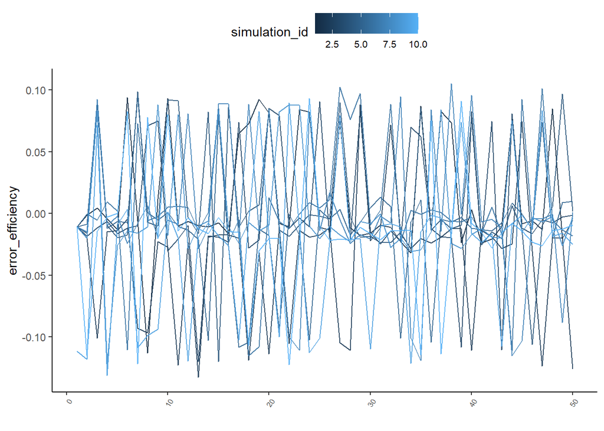

### num_time_100_perfect_substitute_0.3_AR1_I0

|  | Unique | Missing Pct. | Mean | SD | Min | Median | Max |  |
| --- | --- | --- | --- | --- | --- | --- | --- | --- |
| simulation_id | 100 | 0 | 50.500 | 29.011 | 1.000 | 50.500 | 100.000 |  |
| bias | 100 | 0 | -0.001 | 0.018 | -0.040 | -0.001 | 0.041 |  |
| rmse | 100 | 0 | 0.052 | 0.007 | 0.038 | 0.051 | 0.090 |  |

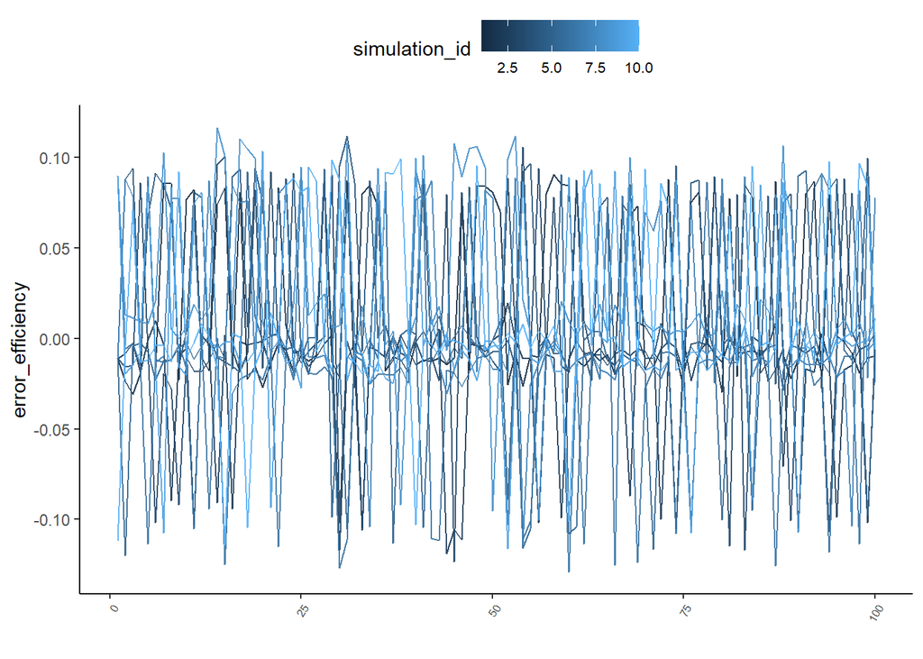

### num_time_200_perfect_substitute_0.3_AR1_I0

|  | Unique | Missing Pct. | Mean | SD | Min | Median | Max |  |
| --- | --- | --- | --- | --- | --- | --- | --- | --- |
| simulation_id | 100 | 0 | 50.500 | 29.011 | 1.000 | 50.500 | 100.000 |  |
| bias | 100 | 0 | 0.009 | 0.016 | -0.035 | 0.013 | 0.038 |  |
| rmse | 100 | 0 | 0.052 | 0.005 | 0.040 | 0.052 | 0.065 |  |

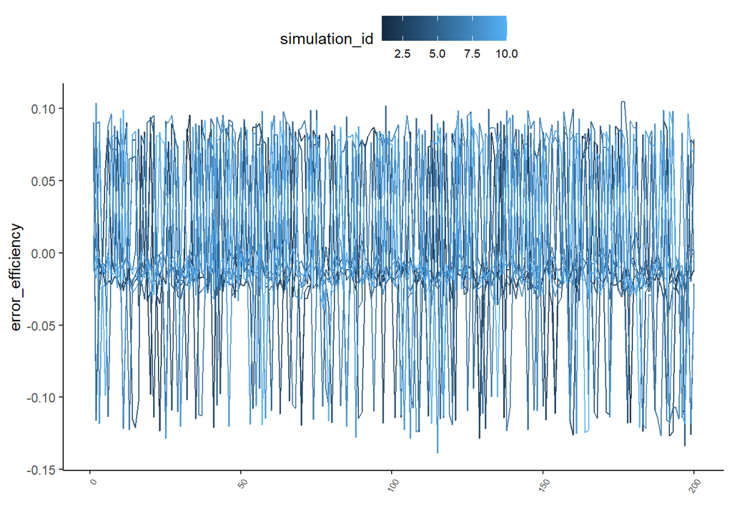

## Nonstationary cobb_douglas

the match elasticity with respect to unemployment is in the range 0.5–0.7.

### num_time_50_cobb_douglas_0.3_AR0_I1

|  | Unique | Missing Pct. | Mean | SD | Min | Median | Max |  |
| --- | --- | --- | --- | --- | --- | --- | --- | --- |
| simulation_id | 100 | 0 | 50.500 | 29.011 | 1.000 | 50.500 | 100.000 |  |
| bias | 100 | 0 | -0.005 | 0.028 | -0.062 | -0.005 | 0.071 |  |
| rmse | 100 | 0 | 0.064 | 0.017 | 0.037 | 0.062 | 0.113 |  |

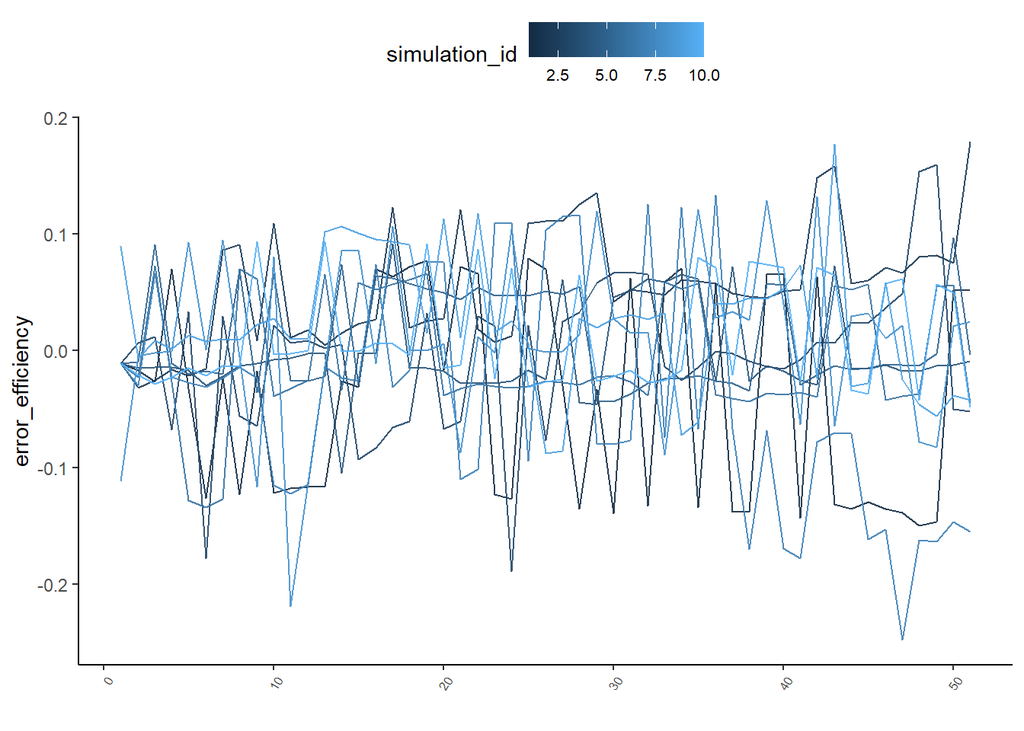

### num_time_100_cobb_douglas_0.3

|  | Unique | Missing Pct. | Mean | SD | Min | Median | Max |  |
| --- | --- | --- | --- | --- | --- | --- | --- | --- |
| simulation_id | 100 | 0 | 50.500 | 29.011 | 1.000 | 50.500 | 100.000 |  |
| bias | 100 | 0 | 0.011 | 0.037 | -0.154 | 0.005 | 0.144 |  |
| rmse | 100 | 0 | 0.065 | 0.026 | 0.040 | 0.055 | 0.199 |  |

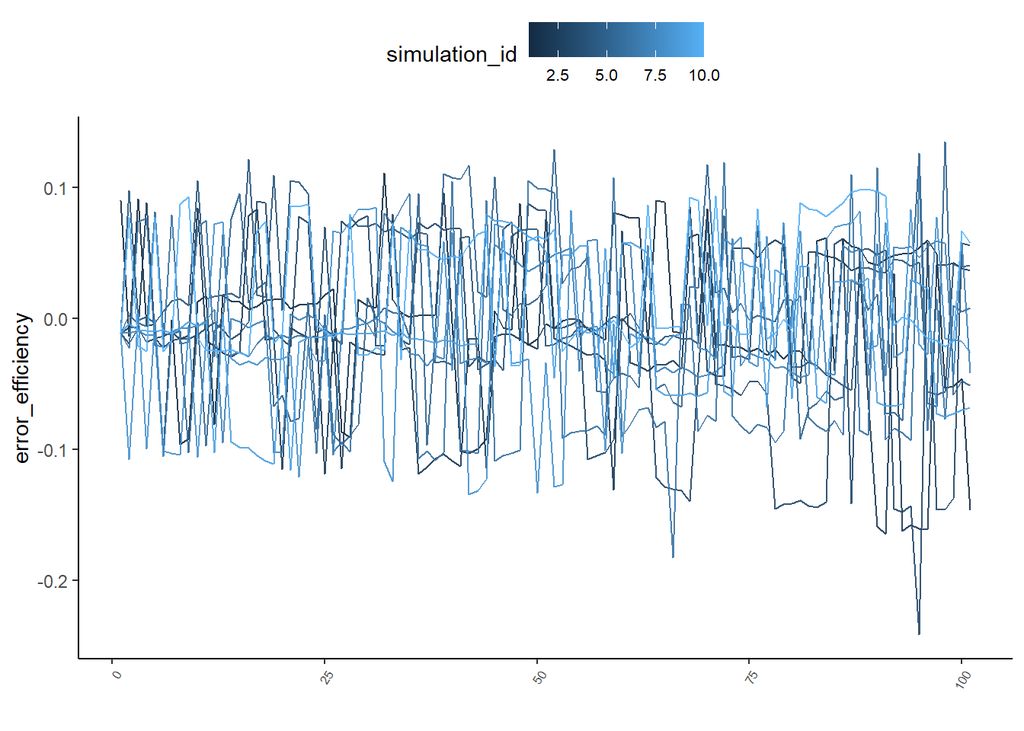

### num_time_200_cobb_douglas_0.3

|  | Unique | Missing Pct. | Mean | SD | Min | Median | Max |  |
| --- | --- | --- | --- | --- | --- | --- | --- | --- |
| simulation_id | 100 | 0 | 50.500 | 29.011 | 1.000 | 50.500 | 100.000 |  |
| bias | 100 | 0 | 0.008 | 0.035 | -0.091 | 0.005 | 0.126 |  |
| rmse | 100 | 0 | 0.067 | 0.023 | 0.041 | 0.061 | 0.162 |  |

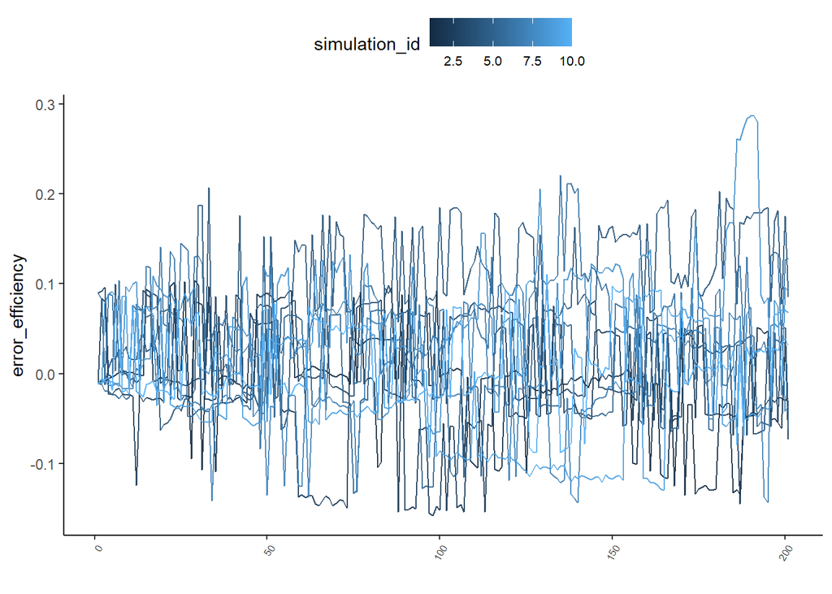

## Nonstationary perfect_substitute

the match elasticity with respect to unemployment is in the range 0.5–0.7.

### num_time_50_perfect_substitute_0.3

|  | Unique | Missing Pct. | Mean | SD | Min | Median | Max |  |
| --- | --- | --- | --- | --- | --- | --- | --- | --- |
| simulation_id | 100 | 0 | 50.500 | 29.011 | 1.000 | 50.500 | 100.000 |  |
| bias | 100 | 0 | -0.015 | 0.034 | -0.097 | -0.019 | 0.081 |  |
| rmse | 100 | 0 | 0.069 | 0.019 | 0.044 | 0.067 | 0.137 |  |

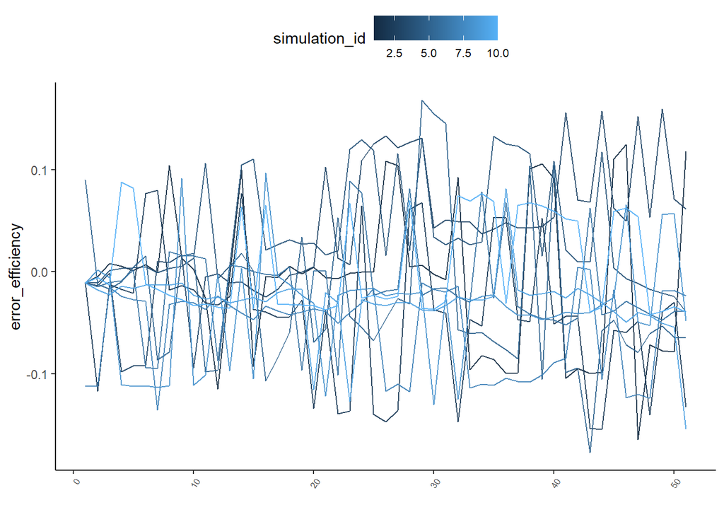

### num_time_100_perfect_substitute_0.3

|  | Unique | Missing Pct. | Mean | SD | Min | Median | Max |  |
| --- | --- | --- | --- | --- | --- | --- | --- | --- |
| simulation_id | 100 | 0 | 50.500 | 29.011 | 1.000 | 50.500 | 100.000 |  |
| bias | 100 | 0 | -0.005 | 0.049 | -0.138 | -0.010 | 0.136 |  |
| rmse | 100 | 0 | 0.078 | 0.027 | 0.039 | 0.073 | 0.178 |  |

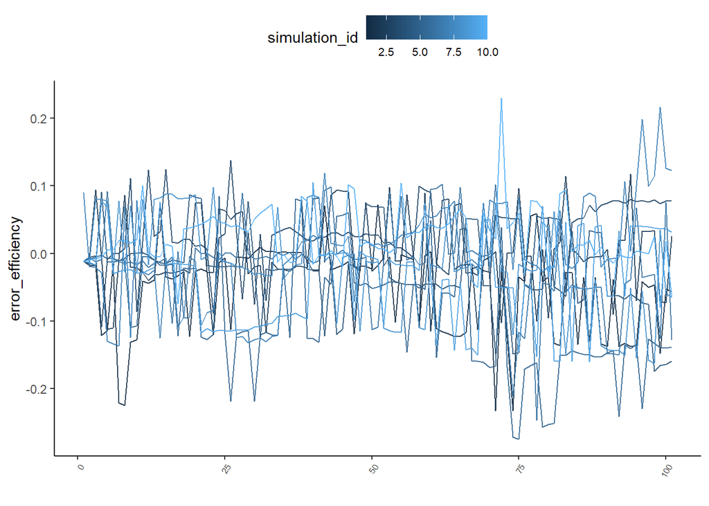

### num_time_200_perfect_substitute_0.3

|  | Unique | Missing Pct. | Mean | SD | Min | Median | Max |  |
| --- | --- | --- | --- | --- | --- | --- | --- | --- |
| simulation_id | 100 | 0 | 50.500 | 29.011 | 1.000 | 50.500 | 100.000 |  |
| bias | 100 | 0 | 0.004 | 0.060 | -0.215 | -0.003 | 0.168 |  |
| rmse | 100 | 0 | 0.084 | 0.038 | 0.043 | 0.073 | 0.247 |  |

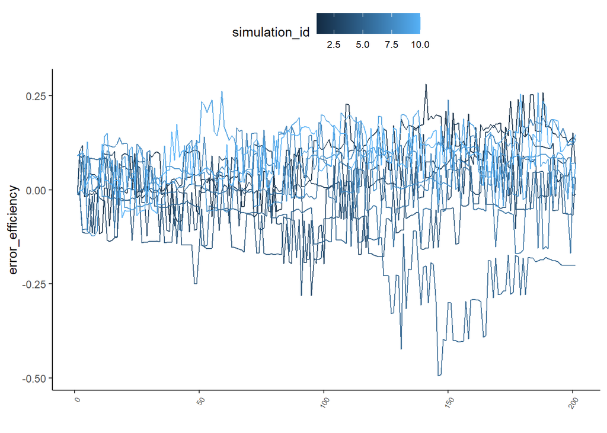